# Machine Learning Project

Christopher Stanwood

September 2, 2018

## Overview

The aim of this assignment is to determine how well people do a simple dumbbell exercise, as described here:

http://web.archive.org/web/20161224072740/http:/groupware.les.inf.puc-rio.br/har

with the following data:

https://d396qusza40orc.cloudfront.net/predmachlearn/pml-training.csv

https://d396qusza40orc.cloudfront.net/predmachlearn/pml-testing.csv

The outcome variable is called “classe”, which takes the five levels “A”, “B”, “C”, “D”, “E”. Any other variables may be used to predict the outcome.

## Cleaning the Data

First of all, import some libraries we will need later:

```r
library(data.table)
library(dplyr)
library(caret)
library(doParallel)
```

We need to read in the data. I prefer to use the data.table package because it is very fast and flexible:

```r
pml_training <- fread("pml-training.csv", stringsAsFactors = T, data.table = F)
pml_testing <- fread("pml-testing.csv", stringsAsFactors = T, data.table = F)
```

Basic data exploration:

```r
dim(pml_training)
```

```
## [1] 19622   160
```

```r
summary(pml_training)
```

[output not shown]

[output cut: 313 more lines]

[output not shown]

There are many columns which are mostly NA or blank. I found these very hard to work with, and so I will remove them, with code which is a modified version of the code given here:

https://stackoverflow.com/questions/24027605/determine-the-number-of-na-values-in-a-column

```r
na_count <- data.frame(nas = sapply(pml_training, function(y) length(which(is.na(y))) +
    length(which(y == ""))))
na_count <- cbind(name = rownames(na_count), na_count)
dropcolumns <- filter(na_count, nas > 19000)$name
training <- select(pml_training, -one_of(as.character(dropcolumns)))
```

Also, the first 7 columns do not contain data that appears relevant to predictions, so I will remove them also:

```r
head(pml_training[, 1:7])
```

```
##   V1 user_name raw_timestamp_part_1 raw_timestamp_part_2   cvtd_timestamp
## 1  1  carlitos           1323084231               788290 05/12/2011 11:23
## 2  2  carlitos           1323084231               808298 05/12/2011 11:23
## 3  3  carlitos           1323084231               820366 05/12/2011 11:23
## 4  4  carlitos           1323084232               120339 05/12/2011 11:23
## 5  5  carlitos           1323084232               196328 05/12/2011 11:23
## 6  6  carlitos           1323084232               304277 05/12/2011 11:23
##   new_window num_window
## 1         no         11
## 2         no         11
## 3         no         11
## 4         no         12
## 5         no         12
## 6         no         12
```

```r
training <- (select(training, -c(1:7)))
```

## Building the Model & Cross Validation

I choose to use Random Forests because i) this is a highly accurate method and ii) I am not concerned with interpretability.

We will use 10-fold cross validation, in order to increase accuracy and to get an estimate of how well this will work with out of sample data.

Set up cross validation:

```r
train_control <- trainControl(method = "cv", number = 10)
```

Enable parallel processing, to speed up calculations:

```r
cl <- makeCluster(detectCores())
registerDoParallel(cl)
```

Finally create the model (warning: this takes about 20 minutes on my windows laptop, even using all cores):

```r
modelRF <- train(classe ~ ., method = "rf", data = training, trControl = train_control)
stopCluster(cl)
```

## Evaluation of Model

```r
modelRF
```

```
## Random Forest
##
## 19622 samples
##    52 predictor
##     5 classes: 'A', 'B', 'C', 'D', 'E'
##
## No pre-processing
## Resampling: Cross-Validated (10 fold)
## Summary of sample sizes: 17661, 17661, 17659, 17660, 17659, 17660, ...
## Resampling results across tuning parameters:
##
##   mtry  Accuracy   Kappa
##    2    0.9954135  0.9941980
##   27    0.9952097  0.9939404
##   52    0.9901639  0.9875573
##
## Accuracy was used to select the optimal model using the largest value.
## The final value used for the model was mtry = 2.
```

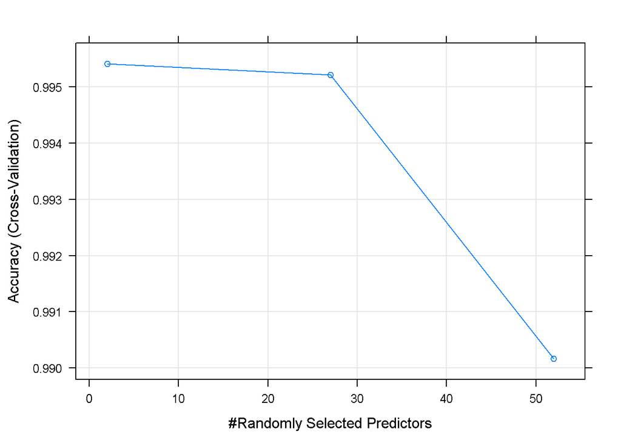

```r
plot(modelRF)
```

Also the out of box error is very low, at 0.46%:

```r
modelRF$finalModel
```

```
##
## Call:
##  randomForest(x = x, y = y, mtry = param$mtry)
##                Type of random forest: classification
##                      Number of trees: 500
## No. of variables tried at each split: 2
##
##         OOB estimate of  error rate: 0.46%
## Confusion matrix:
##      A    B    C    D    E  class.error
## A 5577    2    0    0    1 0.0005376344
## B   12 3781    4    0    0 0.0042138530
## C    0   20 3401    1    0 0.0061367621
## D    0    0   41 3172    3 0.0136815920
## E    0    0    1    6 3600 0.0019406709
```

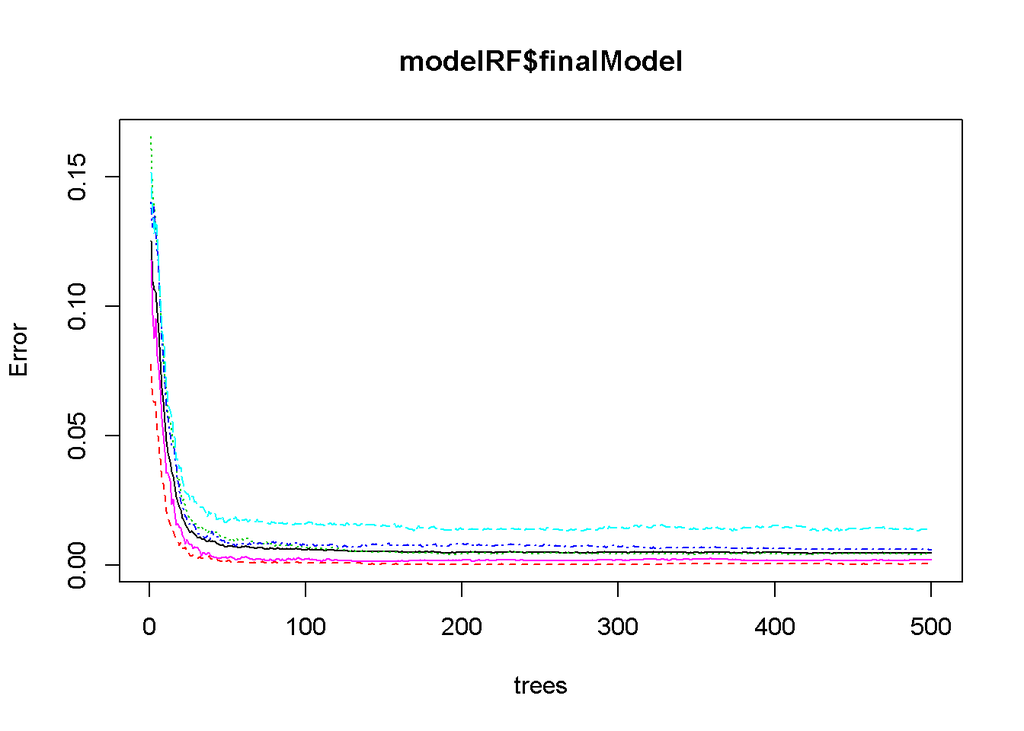

```r
plot(modelRF$finalModel)
```

From this, I anticipate an out of sample error under 1%.

## Prediction of test cases

I will prepare the test cases in the same way as the training data:

```r
testing <- select(pml_testing, -one_of(as.character(dropcolumns)))
testing <- (select(testing, -c(1:7)))
```

Finally I will use the model to make predictions on the test data:

```r
predRF <- predict(modelRF, testing)
```

I deliberately did not show the results in order to comply with the Coursera honour code. However, the final predictions for the test data did well on the final quiz.

## Conclusion

The Random Forest algorithm, with 10 fold cross validation, created an accurate model for making predictions on out of sample test data. The drawbacks are that the model was time-consuming to build and is not easy to interpret.